# Data analysis and visualization using R (1)

using and writing functions in R

Michiel Noback

December 2019

# Contents

- Descriptive statistics
- General purpose functions
- Reading and writing textual data (second serving)
- Some programming basics: Flow control and writing functions

# Descriptive statistics

# Descriptive stats functions

- R provides a wealth of descriptive statistics functions
- They are listed on the next two slides
- The ones with an asterisk are described in more detail.

# Descriptive statistics functions (1)

| function | purpose |
| --- | --- |
| mean( ) | mean |
| median( ) | median |
| min( ) | minimum |
| max( ) | maximum |
| range( ) | min and max |

# Descriptive statistics functions (2)

| function | purpose |
| --- | --- |
| var( ) | variance s^2 |
| sd( ) | standard deviation s |
| summary( ) | 6-number summary |
| quantile( ) * | quantiles |
| IQR( ) * | interquantile range |

# The `quantile()` function

- Gives the data values corresponding to the specified quantiles
- The function defaults to the quantiles `0% 25% 50% 75% 100%`

```r
quantile(ChickWeight$weight)
```

```
    0%    25%    50%    75%   100%
 35.00  63.00 103.00 163.75 373.00
```

```r
quantile(ChickWeight$weight, probs = seq(0, 1, 0.2))
```

```
   0%   20%   40%   60%   80%  100%
 35.0  57.0  85.0 126.0 181.6 373.0
```

# Interquantile range `IQR()`

- Gives the range between 25% and 75% quantiles

```r
IQR(ChickWeight$weight)
```

```
[1] 100.75
```

```r
## same as
quantile(ChickWeight$weight)[4] - quantile(ChickWeight$weight)[2]
```

```
   75%
100.75
```

```r
## same as
diff(quantile(ChickWeight$weight, probs = c(0.25, 0.75)))
```

```
   75%
100.75
```

# `boxplot()` is `summary()` visualized

- Boxplot is a graph of the 5-number summary, but `summary()` also gives the mean

```r
summary(ChickWeight$weight)
```

```
   Min. 1st Qu.  Median    Mean 3rd Qu.    Max.
   35.0    63.0   103.0   121.8   163.8   373.0
```

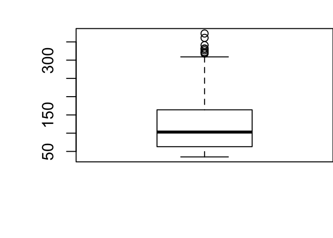

```r
boxplot(ChickWeight$weight)
```

# General purpose functions

# Remove objects from memory

- When working with large datasets it may be usefull free some memory one in a while (i.e. intermediate results)
- use `ls()` to see what is in menory
- use `rm()` to delete single items: `rm(genes)`, `rm(x, y, z)`
- clear all by typing `rm(list = ls())`

# File system operations

- `getwd()` returns the current working directory
- `setwd(</path/to/folder>)` sets the current working directory
- `dir()`, `dir(path)` lists the contents of the current directory or of *path*
- *path* can be defined as
  - Windows: `"E:\\emile\\datasets"`
  - Linux/Mac: `"~/datasets"` or `"/home/emile/datasets"`

# Glueing text pieces: `paste()`

- Use `paste()` to combine elements into a string

```r
paste(1, 2, 3)
```

```
[1] "1 2 3"
```

```r
paste(1, 2, 3, sep="-")
```

```
[1] "1-2-3"
```

```r
paste(1:12, month.abb)
```

```
 [1] "1 Jan"  "2 Feb"  "3 Mar"  "4 Apr"  "5 May"  "6 Jun"  "7 Jul"  "8 Aug"  "9 Sep"  "10 Oct"
[11] "11 Nov" "12 Dec"
```

# Investigate structure: `str()`

- Use `str()` to investigate the structure of a complex object

```r
str(chickwts)
```

```
'data.frame':   71 obs. of  2 variables:
 $ weight: num  179 160 136 227 217 168 108 124 143 140 ...
 $ feed  : Factor w/ 6 levels "casein","horsebean",..: 2 2 2 2 2 2 2 2 2 2 ...
```

# A local namespace: `with()`

- When you have a piece of related code operating on a single dataset, use `with()` so you don’t have to type its name all the time.

```r
with(airquality, {
  mdl <- lm(Solar.R ~ Temp)
  plot(Solar.R ~ Temp)
  abline(mdl)
})
```

- Local variables such as `mdl` will not end up in the global environment
- Note the use of the tilde `~` character to specify a *formula*.
- You can read the formula `A ~ B` as *“A as a function of B”*

# Convert numeric vector to factor: `cut()`

- Sometimes it is useful to work with a factor instead of a numeric vector.
- For instance, when working with a Body Mass Index (bmi) variable it may be nice to split this into a factor for some analyses.
- The function `cut()` is used for this.

# `cut()` demo

- Suppose you have the following fictitious dataset

```r
## body mass index
bmi <- c(22, 32, 21, 37, 28, 34, 26, 29,
         41, 18, 22, 27, 32, 31, 26)
## year income * 1000 euros
income <- c(23, 14, 20, 13, 47, 15, 38, 29,
            12, 25, 33, 24, 19, 42, 38)
my.data <- data.frame(bmi = bmi, income = income)
```

- You can of course look at income as a function of bmi using a scatter plot:

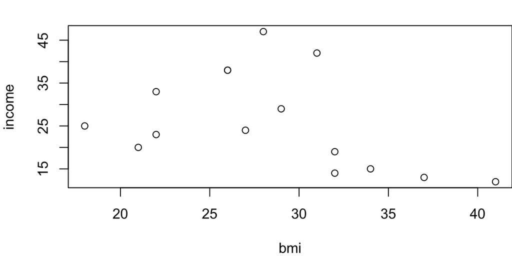

```r
with(my.data, plot(income ~ bmi))
```

…but wouldn’t it be nice to look at the bmi categories as defined by the WHO? - use `cut()`

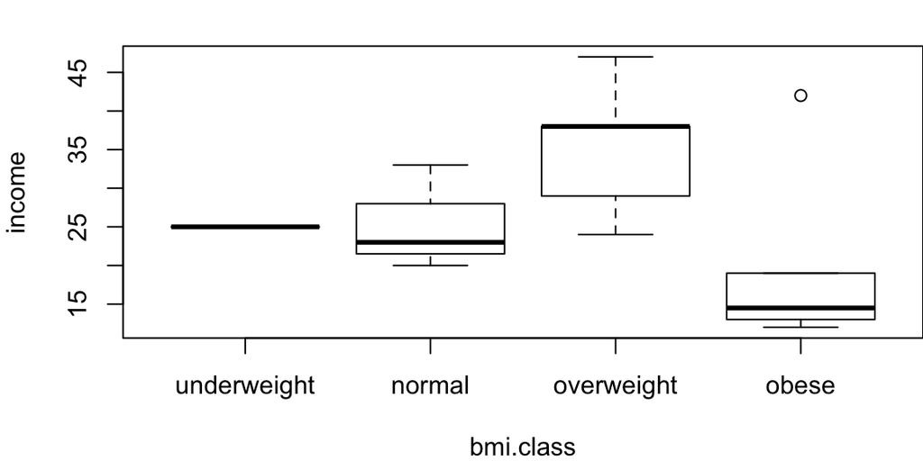

```r
my.data$bmi.class <- cut(bmi,
    breaks = c(0, 18.5, 25.0, 30.0, Inf), right = F,
    labels = c("underweight", "normal", "overweight", "obese"),
    ordered_result = T)
with(my.data, boxplot(income ~ bmi.class))
```

# File I/O revisited

# Data file structure

Whatever the contents of a file, you always need to address (some of) these questions:

- Are there comment lines at the top?
- Is there a header line with column names?
- What is the column separator?
- Are there quotes around character data?
- How are missing values encoded?
- How are numeric values encoded?
- Are there dates (a special challenge)
- What is the type in each column?
  - character / numeric / factor / date/time

# Some `read.table()` arguments

| arg | specifies | example |
| --- | --- | --- |
| **sep** | field separator | sep = “:” |
| **header** | is there a header | header = F |
| **dec** | decimal format | dec = “,” |
| **comment.char** | comment line start | comment.char = "" |
| **na.strings** | NA value | na.strings = “-” |
| **as.is** | load as character | as.is = c(1,4) |
| **stringsAsFactors** | load strings as factors | stringsAsFactors = F |

# The data reading workflow

Always apply this sequence of steps and repeat until you are satisfied with the result:

1. `read.table()` with arguments that seem OK
2. Check the result at least with `str()` and `head()` and verify that the columns have the correct data type.
   - Factors where numeric expected indicate missed “NA” values!
3. Adjust the read.table parameters
4. Rinse and repeat

# Writing data to file

- writing a data frame / matrix / vector to file:
  - `write.table(myData, file="file.csv")`
- Standard is a comma-separated file with both column- and row names, unless otherwise specified:
  - `col.names = F`
  - `row.names = F`
  - `sep = ";"`
  - `sep = "\t" # tab-separated`

# Saving R objects to file

Use the `save()` function to write R objects to file for later use. This is especially handy with intermediate results in long analysis workflows.

```r
x <- stats::runif(20)
y <- list(a = 1, b = TRUE, c = "oops")
save(x, y, file = "xy.RData")
```

# Writing plot to file

- Use `width` and `height` to specify size
- Default unit is pixels
- Use other unit: `units = "mm"`

```r
png("/path/to/your/file.png",
    width = 700, height = 350, units = "mm")
plot(cars)
dev.off() # don't forget this one!
```

# Pattern matching

# What is pattern matching

Pattern matching is the process of finding, locating, extracting and replacing patterns in character data that usually cannot be literally described.

For instance, it is easy enough to look for the word “Chimpansee” in a vector containing animal species names:

```r
animals = c("Chimpanzee", "Cow", "Camel")
animals == "Chimpanzee"
```

```
[1]  TRUE FALSE FALSE
```

What are you going to do if there are multiple variants of the word you are looking for? This?

```r
animals = c("Chimpanzee", "Chimp", "chimpanzee", "Pan troglodytes")
animals == "Chimpanzee" | animals == "Chimp" | animals == "chimpanzee"
```

```
[1]  TRUE  TRUE  TRUE FALSE
```

The solution here is not using literals, but describe *patterns*.

Look at the above example. How would you describe a pattern that would correctly identify all Chimpanzee occurrences?

Is you pattern something like this?

*A letter C in upper-or lower case followed by ‘himp’ followed by nothing or ‘anzee’*

In programming we use *regular expressions* or *RegEx* to describe such patterns:

`[Cc]himp(anzee)?`

```r
grepl("[Cc]himp(anzee)?", animals)
```

```
[1]  TRUE  TRUE  TRUE FALSE
```

# Functions using regex

- **finding** Does an element contain a pattern (TRUE/FALSE)? `grepl(pattern, string)`
- **locating** Which elements contain a pattern (INDEX)? `grep(pattern, string)`
- **extracting** Get the content of matching elements `grep(pattern, string, value = TRUE)`
- **replace** Replace the first occurrence of the pattern `sub(pattern, replacement, string)`
- **replace all** Replace all occurrences of the pattern `gsub(pattern, replacement, string)`

# Regex syntax

A regex can be build out of any combination of

- **character sequences** - Literal sequences, such as ‘chimp’
- **character classes** - A listing of possibilities for a single position. Between brackets: `[adgk]` means ‘a’ or ‘d’ or ‘g’ or ‘k’. Use a hyphen to create a series: `[3-9]` means digits 3 through 9 and `[a-zA-Z]` means all alphabet characters. `[^adgk]` means anything *but* a, d, g or k. A special case is `.`: any character.
- **alternatives** - Are defined by the pipe symbol `|`
- **quantifiers** - How many times the preceding block should occur. See next slide
- **anchors** - `^` means matching at the start of a string. `$` means at the end.

# Cheatsheet

An excellent cheatsheet from the RStudio website is also included here

# Quantifiers

- **`*`**: 0 or more times
- **`+`**: 1 or more times
- **`?`**: 0 or 1 time
- **`{n}`**: exactly `n` times
- **`{n,}`**: at least `n` times
- **`{,n}`**: at most `n` times
- **`{n, m}`**: at least `n` and at most `m` times.

# Some examples

This is the recognition sequence for the *HincII* restriction endonuclease:

```
5'-GTYRAC-3'
3'-CARYTG-5'
```

How would you define a regular expression that is equally precise?

Ambiguity codes can be found here

```r
HincII_rs <- "GT[CT][AG]AC"
sequences <- c("GTCAAC",
               "GTCGAC",
               "GTTGAC",
               "aGTTAACa",
               "GTGCAC")
grep(pattern = HincII_rs, x = sequences, value = TRUE)
```

```
[1] "GTCAAC"   "GTCGAC"   "GTTGAC"   "aGTTAACa"
```

# Dutch dates

Here are some Dutch dates, in different accepted formats. The last two are not a correct notation. Create a RegEx that will determine whether an element contains a Dutch date string.

```r
dates <- c("15/2/2019", "15-2-2019", "15-02-2019", "015/2/20191", "15/2/20191")
dateRegex <- "[0-9]{2}[/-][0-9]{1,2}[/-][0-9]{4}"
grep(pattern = dateRegex, x = dates, value = TRUE)
```

```
[1] "15/2/2019"   "15-2-2019"   "15-02-2019"  "015/2/20191" "15/2/20191"
```

Why were the last two matched?  
Because the pattern is there, embedded in a longer string.  
We have to *anchor* the pattern to be more specific.

# Anchoring

Using anchoring, you can make sure the string is not longer than you explicitly state:

```r
dates <- c("15/2/2019", "15-2-2019", "15-02-2019", "015/2/20191", "15/2/20191")
dateRegex <- "^[0-9]{2}[/-][0-9]{1,2}[/-][0-9]{4}$"
grep(pattern = dateRegex, x = dates, value = TRUE)
```

```
[1] "15/2/2019"  "15-2-2019"  "15-02-2019"
```

Now it is correct.

# Special character classes

Since patterns such as `[0-9]` accur so frequently, they have dedicated character classes such as `[[:digit:]]`. The most important other ones are

- **digits** `[[:digit:]]` or `\\d`: equivalent to `[0-9]`
- **alphabet characters** `[[:alpha:]]`: equivalent to `[a-zA-Z]`
- **lowercase characters** `[[:lower:]]`: equivalent to `[a-z]`
- **uppercase characters** `[[:upper:]]`: equivalent to `[A-Z]`
- **whitespace characters** `[[:space:]]` or `\\s`: Space, tab, vertical tab, newline, form feed, carriage return
- **punctuation characters** `[[:punct:]]`: One of !"#$%&’()*+,-./:;<=>?@[]^_`{|}~

(have a look at the cheat sheet for all)

Here is the same example, this time using these predefined character classes

```r
dates <- c("15/2/2019", "15-2-2019", "15-02-2019", "15022019", "15/2/20191")
dateRegex <- "[[:digit:]]{2}[/-]\\d{1,2}[/-]\\d{4}"
grep(pattern = dateRegex, x = dates, value = TRUE)
```

```
[1] "15/2/2019"  "15-2-2019"  "15-02-2019" "15/2/20191"
```

# Postal codes

Here are some Dutch zip (postal) codes, in different accepted formats. The last two are not a correct notation. Create a RegEx that will determine whether an element contains a Dutch zip code.

```r
zips <- c("1234 AA", "2345-BB", "3456CC", "4567 dd", "56789aa", "6789a_")
zips
```

```
[1] "1234 AA" "2345-BB" "3456CC"  "4567 dd" "56789aa" "6789a_"
```

# Prosite patterns

[Prosite](https://prosite.expasy.org/) is a database of amino acid sequence motifs. One of them is the Histidine Triad profile (PDOC00694).

```
[NQAR]-x(4)-[GSAVY]-x-[QFLPA]-x-[LIVMY]-x-[HWYRQ]-
[LIVMFYST]-H-[LIVMFT]-H-[LIVMF]-[LIVMFPT]-[PSGAWN]
```

- Write this down as a RegEx
- Was that efficient? Using the `gsub()` function, can you convert it in a RegEx using code? It may take several iterations. Was that efficient?
- Next, use an appropriate function to find if, and where, this pattern is located within the sequences in file `data/hit_proteins.txt` (here)

Amino Acid codes and Prosite pattern encoding can be found here

# Locating and Extracting

This is outside the scope of this first acquaintance. The `stringr` package from the tidyverse is much better at this than the base R functions. And the tidyverse is in the next course…